# R Workshop UCSD

Ben Wilson

March 3, 2016

# R 101

# Content Overview

- R & Rstudio
- dplyr
- ggplot2
- Rmarkdown
- Bayesian Belief Networks

# Why R?

# Why R?

- http://pypl.github.io/PYPL.html
  - Ranked 10 in popularity (Mar 2016)
- http://blog.revolutionanalytics.com/2015/11/new-surveys-show-continued-popularity-of-r.html
  - Skill second only to data analytics (roughly tied with python)

# What is R?

R is a language and environment for statistical computing and graphics.

- Compared to python
  - Built for data analysis instead of a general programming language
  - Python + Pandas are a similar tool kit
  - Easily cross platform
- Compared to Matlab
  - Built for ‘data.frames’ vs matrices
  - More flexible with data types
  - Free

# When Should I Use R?

R is useful for investigating data, creating models, and reports among other things.

Personally I use R to investigate new data, prototype models, and do ad-hoc analysis.

http://shiny.rstudio.com/gallery/

# Base R

# Base R

```
2 + 3
```

```
## [1] 5
```

```
8 * 6
```

```
## [1] 48
```

```
8 * 6 == 5
```

```
## [1] FALSE
```

```
cos(pi)
```

```
## [1] -1
```

# Data Frames

```
n <- c(2, 3, 5)
s <- c("aa", "bb", "cc")
b <- c(TRUE, FALSE, TRUE)
df <- data.frame(n, s, b)

df
```

```
##   n  s     b
## 1 2 aa  TRUE
## 2 3 bb FALSE
## 3 5 cc  TRUE
```

# Data Frames (cont)

```
str(df)
```

```
## 'data.frame':    3 obs. of  3 variables:
##  $ n: num  2 3 5
##  $ s: Factor w/ 3 levels "aa","bb","cc": 1 2 3
##  $ b: logi  TRUE FALSE TRUE
```

```
summary(df)
```

```
##        n          s         b
##  Min.   :2.000   aa:1   Mode :logical
##  1st Qu.:2.500   bb:1   FALSE:1
##  Median :3.000   cc:1   TRUE :2
##  Mean   :3.333          NA's :0
##  3rd Qu.:4.000
##  Max.   :5.000
```

# Reading Data into R

# Reading Data into R

Data provided by https://archive.ics.uci.edu/ml/datasets/Online+News+Popularity. Goal is to predict number of shares from metadata of a link on mashable.com.

```
df <- read.csv('data/OnlineNewsPopularity.csv')
nrow(df)
```

```
## [1] 39644
```

K. Fernandes, P. Vinagre and P. Cortez. A Proactive Intelligent Decision Support System for Predicting the Popularity of Online News. Proceedings of the 17th EPIA 2015 - Portuguese Conference on Artificial Intelligence, September, Coimbra, Portugal.

# Names

```
names(df)
```

```
##  [1] "url"                           "timedelta"
##  [3] "n_tokens_title"                "n_tokens_content"
##  [5] "n_unique_tokens"               "n_non_stop_words"
##  [7] "n_non_stop_unique_tokens"      "num_hrefs"
##  [9] "num_self_hrefs"                "num_imgs"
## [11] "num_videos"                    "average_token_length"
## [13] "num_keywords"                  "data_channel_is_lifestyle"
## [15] "data_channel_is_entertainment" "data_channel_is_bus"
## [17] "data_channel_is_socmed"        "data_channel_is_tech"
## [19] "data_channel_is_world"         "kw_min_min"
## [21] "kw_max_min"                    "kw_avg_min"
## [23] "kw_min_max"                    "kw_max_max"
## [25] "kw_avg_max"                    "kw_min_avg"
## [27] "kw_max_avg"                    "kw_avg_avg"
## [29] "self_reference_min_shares"     "self_reference_max_shares"
```

[output cut: 16 more lines]

# Investigate Data

```
summary(df)
```

```
##                                                              url
##  http://mashable.com/2013/01/07/amazon-instant-video-browser/  :    1
##  http://mashable.com/2013/01/07/ap-samsung-sponsored-tweets/   :    1
##  http://mashable.com/2013/01/07/apple-40-billion-app-downloads/:    1
##  http://mashable.com/2013/01/07/astronaut-notre-dame-bcs/      :    1
##  http://mashable.com/2013/01/07/att-u-verse-apps/              :    1
##  http://mashable.com/2013/01/07/beewi-smart-toys/              :    1
##  (Other)                                                       :39638
##    timedelta     n_tokens_title n_tokens_content n_unique_tokens
##  Min.   :  8.0   Min.   : 2.0   Min.   :   0.0   Min.   :  0.0000
##  1st Qu.:164.0   1st Qu.: 9.0   1st Qu.: 246.0   1st Qu.:  0.4709
##  Median :339.0   Median :10.0   Median : 409.0   Median :  0.5392
##  Mean   :354.5   Mean   :10.4   Mean   : 546.5   Mean   :  0.5482
##  3rd Qu.:542.0   3rd Qu.:12.0   3rd Qu.: 716.0   3rd Qu.:  0.6087
##  Max.   :731.0   Max.   :23.0   Max.   :8474.0   Max.   :701.0000
##
##  n_non_stop_words    n_non_stop_unique_tokens   num_hrefs
##  Min.   :   0.0000   Min.   :  0.0000         Min.   :  0.00
##  1st Qu.:   1.0000   1st Qu.:  0.6257         1st Qu.:  4.00
##  Median :   1.0000   Median :  0.6905         Median :  8.00
##  Mean   :   0.9965   Mean   :  0.6892         Mean   : 10.88
##  3rd Qu.:   1.0000   3rd Qu.:  0.7546         3rd Qu.: 14.00
##  Max.   :1042.0000   Max.   :650.0000         Max.   :304.00
##
##  num_self_hrefs       num_imgs         num_videos    average_token_length
##  Min.   :  0.000   Min.   :  0.000   Min.   : 0.00   Min.   :0.000
##  1st Qu.:  1.000   1st Qu.:  1.000   1st Qu.: 0.00   1st Qu.:4.478
##  Median :  3.000   Median :  1.000   Median : 0.00   Median :4.664
##  Mean   :  3.294   Mean   :  4.544   Mean   : 1.25   Mean   :4.548
##  3rd Qu.:  4.000   3rd Qu.:  4.000   3rd Qu.: 1.00   3rd Qu.:4.855
##  Max.   :116.000   Max.   :128.000   Max.   :91.00   Max.   :8.042
##
##   num_keywords    data_channel_is_lifestyle data_channel_is_entertainment
##  Min.   : 1.000   Min.   :0.00000           Min.   :0.000
##  1st Qu.: 6.000   1st Qu.:0.00000           1st Qu.:0.000
##  Median : 7.000   Median :0.00000           Median :0.000
##  Mean   : 7.224   Mean   :0.05295           Mean   :0.178
##  3rd Qu.: 9.000   3rd Qu.:0.00000           3rd Qu.:0.000
##  Max.   :10.000   Max.   :1.00000           Max.   :1.000
##
```

[output cut: 97 more lines]

```
##  Min.   :-1.0000       Min.   :0.0000     Min.   :-1.00000
##  1st Qu.:-0.1250       1st Qu.:0.0000     1st Qu.: 0.00000
##  Median :-0.1000       Median :0.1500     Median : 0.00000
##  Mean   :-0.1075       Mean   :0.2824     Mean   : 0.07143
##  3rd Qu.:-0.0500       3rd Qu.:0.5000     3rd Qu.: 0.15000
##  Max.   : 0.0000       Max.   :1.0000     Max.   : 1.00000
##
##  abs_title_subjectivity abs_title_sentiment_polarity     shares
##  Min.   :0.0000         Min.   :0.0000               Min.   :     1
##  1st Qu.:0.1667         1st Qu.:0.0000               1st Qu.:   946
##  Median :0.5000         Median :0.0000               Median :  1400
##  Mean   :0.3418         Mean   :0.1561               Mean   :  3395
##  3rd Qu.:0.5000         3rd Qu.:0.2500               3rd Qu.:  2800
##  Max.   :0.5000         Max.   :1.0000               Max.   :843300
##
```

# Single Column Investigation

```
head(df$shares)
```

```
## [1]  593  711 1500 1200  505  855
```

```
mean(df$shares)
```

```
## [1] 3395.38
```

```
max(df$shares)
```

```
## [1] 843300
```

# Single Column Investigation

```
hist(df$title_sentiment_polarity)
```

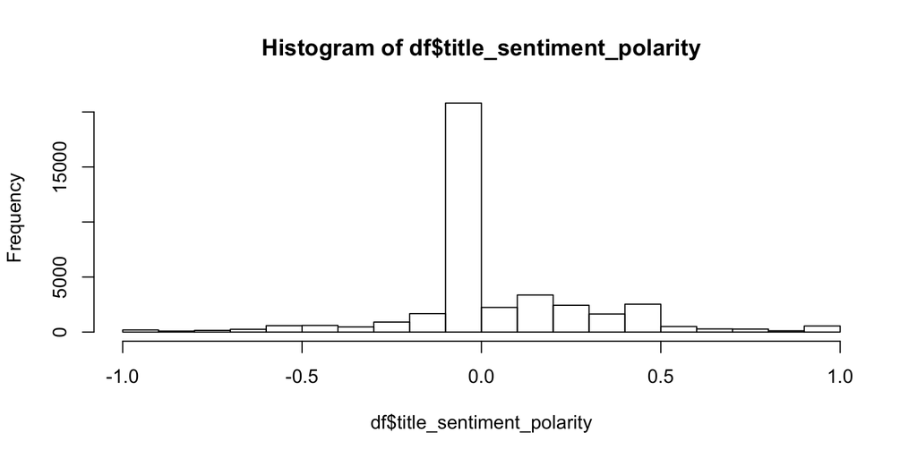

# Correlation Investigation

```
plot(df[1:500, c("num_hrefs", "title_sentiment_polarity", "is_weekend", "shares")])
```

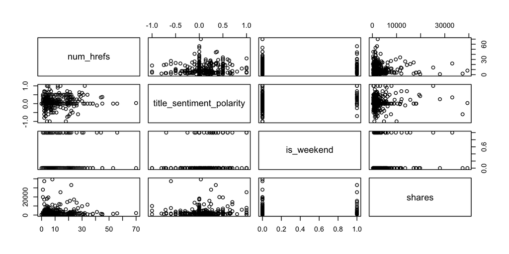

# Packages

# Packages in R

R has a built in package manager. Packages (and R source code, binaries) are hosted on a distributed network (CRAN). http://cran.us.r-project.org/ . There are currently more than 8000 packages available + many more on github.

To install packages one uses the command install.packages() in the R terminal

# Install a couple of packages

Two packages which enable data manipulation and visualization are dplyr and ggplot2. To install them simply type

```
install.packages(c('dplyr', 'ggplot2'))
```

```
library(dplyr)
library(ggplot2)
```

# Dplyr

Dplyr introduces (at least) two ideas to data manipulation in R.

- Pipes

```
  df$shares %>% max()
```

```
## [1] 843300
```

- Verbs

```
  df %>% summarize(n=n())
```

```
##       n
## 1 39644
```

# Group By

Dplyr also introduces many SQL-like verbs in an accessible fashion.

```
df %>%
  group_by(is_weekend) %>%
  summarize(
    n=n(),
    shares_mean=mean(shares),
    shares_max=max(shares)
  )
```

```
## Source: local data frame [2 x 4]
##
##   is_weekend     n shares_mean shares_max
##        (dbl) (int)       (dbl)      (int)
## 1          0 34454    3318.855     843300
## 2          1  5190    3903.394     617900
```

# GGPlot2

# GGPlot2

ggplot2 is a plotting package which enables extremely customizable graphs in an intuitive way.

```
ggplot() +
  geom_histogram(
    data=df,
    aes(x=title_sentiment_polarity)
  )
```

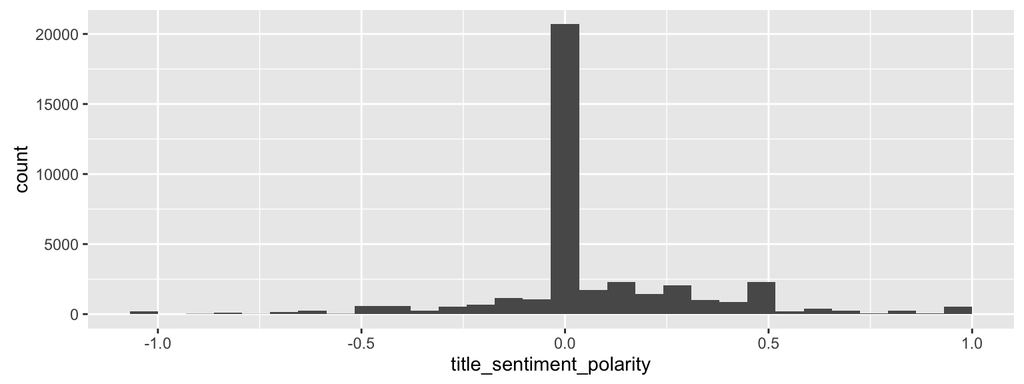

# Machine Learning

# Machine Learning Packages

There are many packages devoted to machine learning in R. Some packages for those interested

- caret
- e1071 (a collection of methods)
- nnet
- gbm
- RWeka
- party

# Sampling Data

Splitting the data into testing and training sets is essential.

```
set.seed(290875)

train_rows <-
  sample(nrow(df), nrow(df) * .10)

train_df <-
  df %>%
  slice(train_rows)

test_df <-
  df %>%
  slice(-train_rows)

head(train_rows)
```

```
## [1] 20313  2319 36055 15638 26211  9257
```

# Running a random forest

```
install.packages('party')
library(party)
```

```
df_cforest <-
  cforest(
    shares ~ avg_positive_polarity + avg_negative_polarity + global_subjectivity + global_sentiment_polarity + global_rate_positive_words + global_rate_negative_words,
    data=train_df,
    control = cforest_unbiased(mtry = 2, ntree = 50)
  )
```

# Predicting New Values

```
test_df <-
  test_df[1:1000, ]

test_df$prediction <-
  Predict(df_cforest, newdata=test_df)

sqrt(mean((test_df$shares - test_df$prediction)^2))
```

```
## [1] 4067.516
```

```
mean(abs(test_df$shares - test_df$prediction))
```

```
## [1] 2361.451
```

# Plotting The Error

```
test_df$is_weekend <- as.factor(test_df$is_weekend)
ggplot() +
  geom_density(
    data=test_df,
    aes(
      x=shares-prediction,
      fill=is_weekend,
      group=is_weekend,
      color=is_weekend
    ),
    alpha=.4
  ) +
  xlim(-5000, 5000) +
  theme_bw()
```

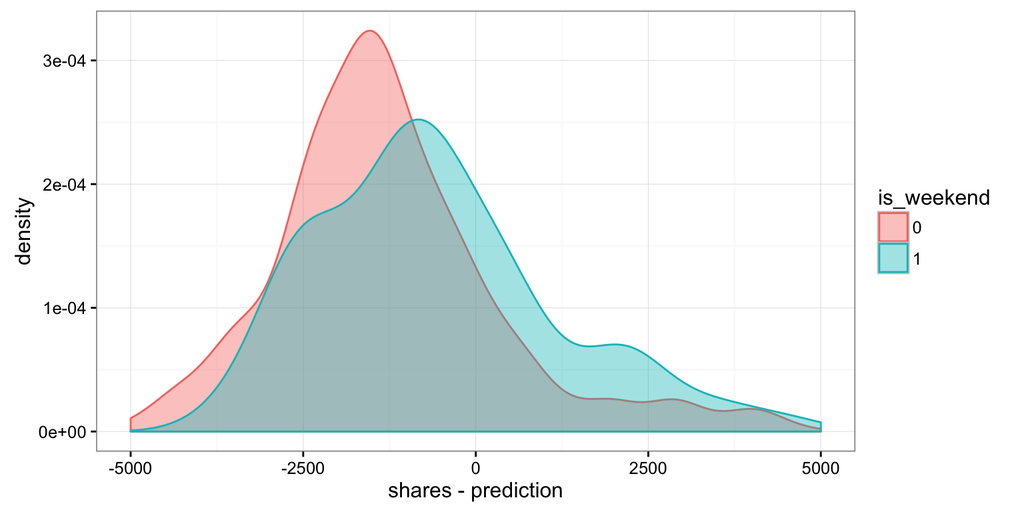

# Plotting the Error

[figure not shown]